# Calculating Walking and cycling trips impedance function- 2005

using a skew vs. kurtois graph to descriptive statistics of data

```
summary statistics
------
min:  5   max:  40
median:  12.5
mean:  13.65625
estimated sd:  8.3882
estimated skewness:  1.310775
estimated kurtosis:  5.068786
```

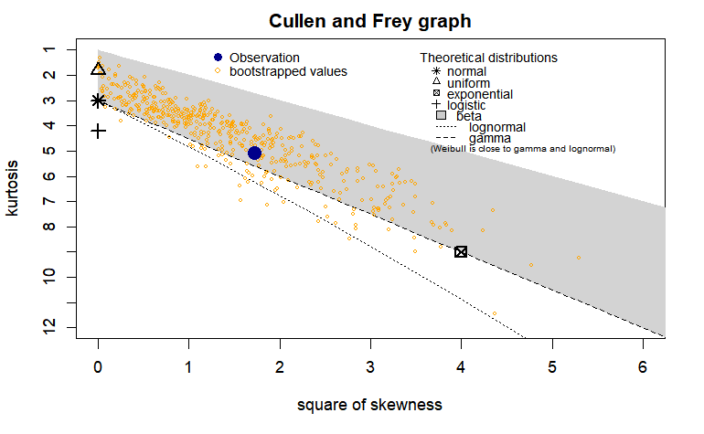

```r
# creating a skew vs. kurtois graph for walking 2005

# Filter the data based on the "destination" column
 w_10_2005 <- walking_2005 %>%
  filter(destination == "10")
descdist(w_10_2005$DURATION %>% unlist() %>% as.numeric(), discrete=FALSE, boot=500)
```

As shown in the Cullen and Frey graph, we see that gamma,normal, weibull, lognormal and exponential will likely be the best fit according to the graph above. Then we compare these models to find the best model.

```r
# Based on the skew vs. kurtois graph the best distribution

#Calculating gamma distribution
gamma_w10_2005_ <- fitdistrplus::fitdist(data=w_10_2005$DURATION%>% unlist() %>% as.numeric(), "gamma", method="mle", optim.method="Nelder-Mead", weights = round(w_10_2005$WGHT_EPI))
fit_dgamma_w1005 <- data.frame(f = dgamma(w_10_2005$DURATION, shape = gamma_w10_2005_$estimate[1], rate = gamma_w10_2005_$estimate[2]), x = w_10_2005$DURATION, type = "Gamma")

summary(gamma_w10_2005_)
```

```
Fitting of the distribution ' gamma ' by maximum likelihood
Parameters :
```

|  | estimate | Std. Error |
| --- | --- | --- |
| shape | 3.8425510 | 0.024931351 |
| rate | 0.3195557 | 0.002214937 |

```
Loglikelihood:  -137415.3   AIC:  274834.6   BIC:  274837.5
Correlation matrix:
         shape     rate
shape 1.000000 0.936061
rate  0.936061 1.000000
```

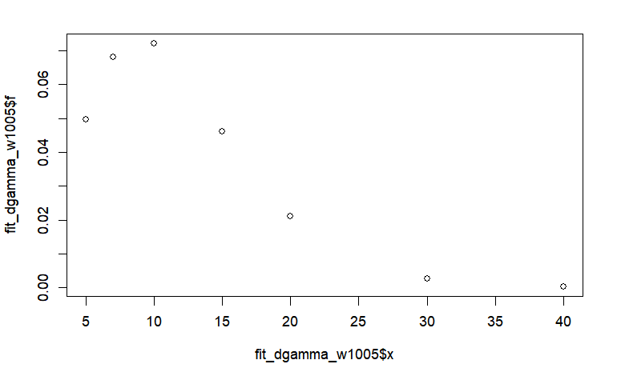

```r
plot(x= fit_dgamma_w1005$x, y=fit_dgamma_w1005$f)
```

```r
#Calculating exponential distribution
exp_w10_2005_ <- fitdistrplus::fitdist(data=w_10_2005$DURATION%>% unlist() %>% as.numeric(), "exp", method="mle", optim.method="Nelder-Mead", weights = round(w_10_2005$WGHT_EPI))
summary(exp_w10_2005_)
```

```
Fitting of the distribution ' exp ' by maximum likelihood
Parameters :
```

|  | estimate | Std. Error |
| --- | --- | --- |
| rate | 0.08315217 | 0.0003974496 |

```
Loglikelihood:  -152581.5   AIC:  305165.1   BIC:  305166.5
```

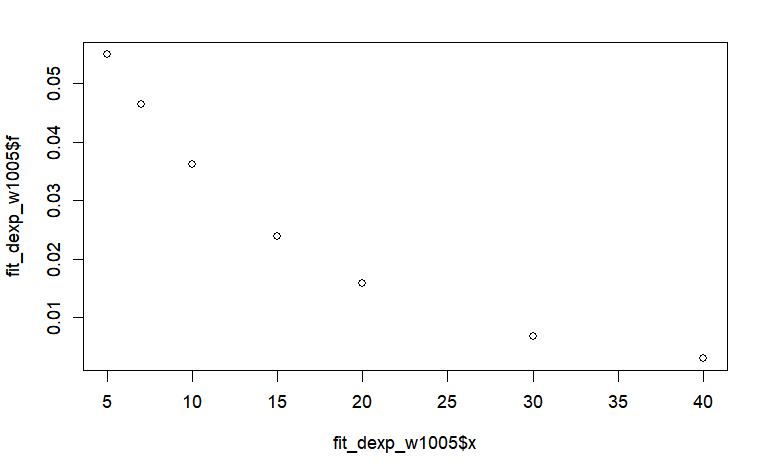

```r
fit_dexp_w1005 <- data.frame(f = dexp(w_10_2005$DURATION, rate = exp_w10_2005_$estimate[1]),
                       x = w_10_2005$DURATION, type = "exp")

plot(x = fit_dexp_w1005$x, y = fit_dexp_w1005$f)
```

```r
#Calculating normal distribution
norm_w10_2005_ <- fitdistrplus::fitdist(data=w_10_2005$DURATION%>% unlist() %>% as.numeric(), "norm", method="mle", optim.method="Nelder-Mead", weights = round(w_10_2005$WGHT_EPI))
summary(norm_w10_2005_)
```

```
Fitting of the distribution ' norm ' by maximum likelihood
Parameters :
```

|  | estimate | Std. Error |
| --- | --- | --- |
| mean | 12.023858 | 0.02899854 |
| sd | 6.066033 | 0.02050641 |

```
Loglikelihood:  -140970.7   AIC:  281945.5   BIC:  281948.4
Correlation matrix:
              mean            sd
mean  1.0000000000 -0.0001334265
sd   -0.0001334265  1.0000000000
```

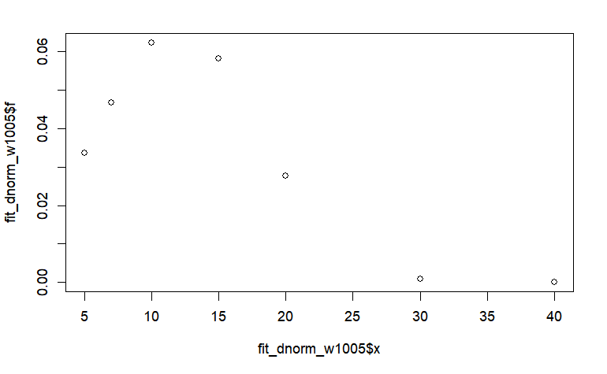

```r
fit_dnorm_w1005 <- data.frame(f = dnorm(w_10_2005$DURATION, mean = norm_w10_2005_$estimate[1], sd = norm_w10_2005_$estimate[2]),  x = w_10_2005$DURATION, type = "norm")

plot(x = fit_dnorm_w1005$x, y = fit_dnorm_w1005$f)
```

```r
#Calculating lognormal distribution
lnorm_w10_2005_ <- fitdistrplus::fitdist(data=w_10_2005$DURATION%>% unlist() %>% as.numeric(), "lnorm", method="mle", optim.method="Nelder-Mead", weights = round(w_10_2005$WGHT_EPI))
summary(lnorm_w10_2005_)
```

```
Fitting of the distribution ' lnorm ' by maximum likelihood
Parameters :
```

|  | estimate | Std. Error |
| --- | --- | --- |
| meanlog | 2.3511175 | 0.002566397 |
| sdlog | 0.5368495 | 0.001814519 |

```
Loglikelihood:  -137756.6   AIC:  275517.2   BIC:  275520.1
Correlation matrix:
              meanlog         sdlog
meanlog  1.0000000000 -0.0001729915
sdlog   -0.0001729915  1.0000000000
```

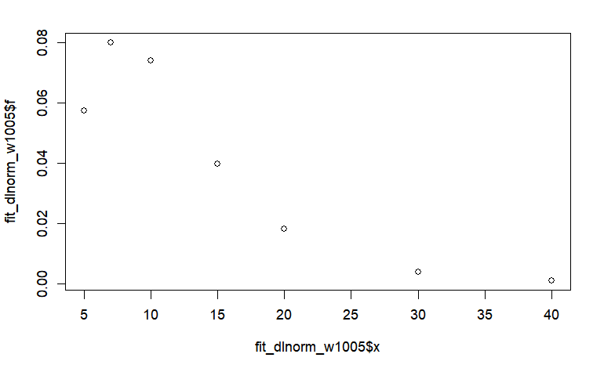

```r
fit_dlnorm_w1005 <- data.frame(f = dlnorm(w_10_2005$DURATION, meanlog = lnorm_w10_2005_$estimate[1], sdlog = lnorm_w10_2005_$estimate[2]),  x = w_10_2005$DURATION, type = "lnorm")

plot(x = fit_dlnorm_w1005$x, y = fit_dlnorm_w1005$f)
```

```r
#Calculating weibull distribution
weibull_w10_2005_ <- fitdistrplus::fitdist(data=w_10_2005$DURATION%>% unlist() %>% as.numeric(), "weibull", method="mle", optim.method="Nelder-Mead", weights = round(w_10_2005$WGHT_EPI))
summary(weibull_w10_2005_)
```

```
Fitting of the distribution ' weibull ' by maximum likelihood
Parameters :
```

|  | estimate | Std. Error |
| --- | --- | --- |
| shape | 2.116172 | 0.00772559 |
| scale | 13.628053 | 0.03253828 |

```
Loglikelihood:  -137995.6   AIC:  275995.2   BIC:  275998.1
Correlation matrix:
          shape     scale
shape 1.0000000 0.3233747
scale 0.3233747 1.0000000
```

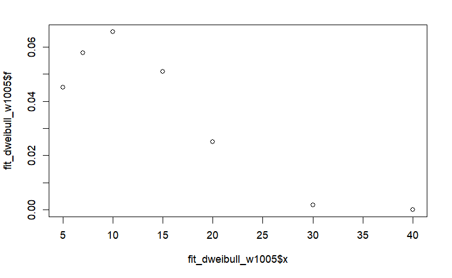

```r
fit_dweibull_w1005 <- data.frame(f = dweibull(w_10_2005$DURATION, shape = weibull_w10_2005_$estimate[1], scale = weibull_w10_2005_$estimate[2]),  x = w_10_2005$DURATION, type = "weibull")

plot(x = fit_dweibull_w1005$x, y = fit_dweibull_w1005$f)
```

Now let’s compare these models AIC and BIC to see which fits the walk data best:

```r
#comparing these models AIC and BIC to see which fits the walk data best:
broom::glance(MASS::fitdistr(w_10_2005$DURATION%>% unlist() %>% as.numeric(),"gamma"))
```

| logLik | AIC | BIC | nobs |
| --- | --- | --- | --- |
| -107.5286 | 219.0573 | 221.9887 | 32 |

```r
broom::glance(MASS::fitdistr(w_10_2005$DURATION%>% unlist() %>% as.numeric(),"exponential"))
```

| logLik | AIC | BIC | nobs |
| --- | --- | --- | --- |
| -115.6543 | 233.3086 | 234.7744 | 32 |

```r
broom::glance(MASS::fitdistr(w_10_2005$DURATION%>% unlist() %>% as.numeric(),"normal"))
```

| logLik | AIC | BIC | nobs |
| --- | --- | --- | --- |
| -112.9565 | 229.913 | 232.8444 | 32 |

```r
broom::glance(MASS::fitdistr(w_10_2005$DURATION%>% unlist() %>% as.numeric(),"lognormal"))
```

| logLik | AIC | BIC | nobs |
| --- | --- | --- | --- |
| -106.996 | 217.992 | 220.9235 | 32 |

```r
broom::glance(MASS::fitdistr(w_10_2005$DURATION%>% unlist() %>% as.numeric(),"weibull"))
```

| logLik | AIC | BIC | nobs |
| --- | --- | --- | --- |
| -108.5899 | 221.1798 | 224.1113 | 32 |

So, lognormal has largest logLik and the smallest AIC and BIC. we will pick lognormal function for walking trips in 2005!

```r
walking_1005_lnorm <- lnorm_w10_2005_
w_10_2005 <- w_10_2005 %>%
 mutate(f_10 = dlnorm(DURATION, walking_1005_lnorm$estimate["meanlog"], walking_1005_lnorm$estimate["sdlog"]))
summary(w_10_2005$f_10)
```

```
    Min.  1st Qu.   Median     Mean  3rd Qu.     Max.
0.000833 0.034305 0.048474 0.045999 0.061425 0.079845
```

### Calculating impedance function for cycling in 2005

```r
count <- sum(cycling_2005$DURATION > 100)
print (count)
```

```
[1] 2
```

```r
cycling_2005 <- cycling_2005 %>% filter(DURATION < 100)
summary(cycling_2005$DURATION)
```

```
   Min. 1st Qu.  Median    Mean 3rd Qu.    Max.
   1.00   10.00   15.00   18.57   25.00   95.00
```

using a skew vs. kurtois graph to descriptive statistics of data:

```
summary statistics
------
min:  1   max:  95
median:  15
mean:  18.56748
estimated sd:  15.63232
estimated skewness:  1.830685
estimated kurtosis:  6.983927
```

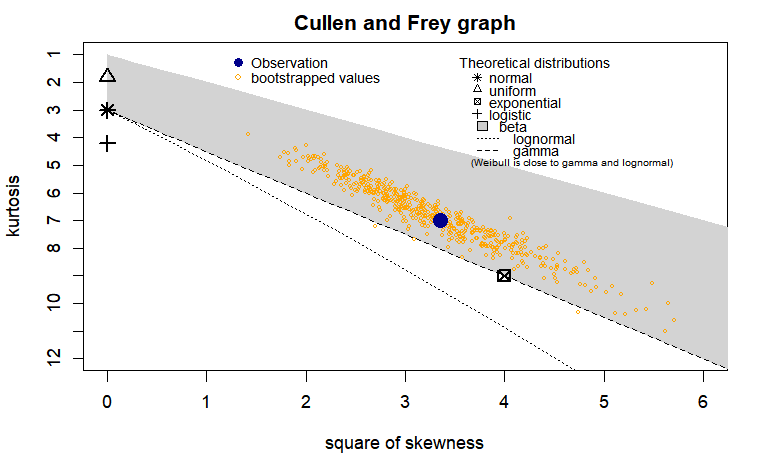

```r
# creating a skew vs. kurtois graph for cycling 2005

descdist(cycling_2005$DURATION %>% unlist() %>% as.numeric(), discrete=FALSE, boot=500)
```

As shown in the Cullen and Frey graph, we see that gamma,weibull, and exponential will likely be the best fit according to the graph above. Then we compare these models to find the best model.

```r
summary(cycling_2005$DURATION)
```

```
   Min. 1st Qu.  Median    Mean 3rd Qu.    Max.
   1.00   10.00   15.00   18.57   25.00   95.00
```

```r
# Based on the skew vs. kurtois graph the best distribution

#Calculating gamma distribution

gamma_c_2005_ <- fitdistrplus::fitdist(data=cycling_2005$DURATION%>% unlist() %>% as.numeric(), "gamma", method="mle", optim.method="Nelder-Mead", weights = round(cycling_2005$WGHT_EPI))
fit_dgamma <- data.frame(f = dgamma(cycling_2005$DURATION, shape = gamma_c_2005_$estimate[1], rate = gamma_c_2005_$estimate[2]), x = cycling_2005$DURATION, type = "gamma")

summary(gamma_c_2005_)
```

```
Fitting of the distribution ' gamma ' by maximum likelihood
Parameters :
```

|  | estimate | Std. Error |
| --- | --- | --- |
| shape | 1.62018295 | 0.0028697050 |
| rate | 0.08466919 | 0.0001753914 |

```
Loglikelihood:  -2078024   AIC:  4156052   BIC:  4156060
Correlation matrix:
          shape      rate
shape 1.0000000 0.8548489
rate  0.8548489 1.0000000
```

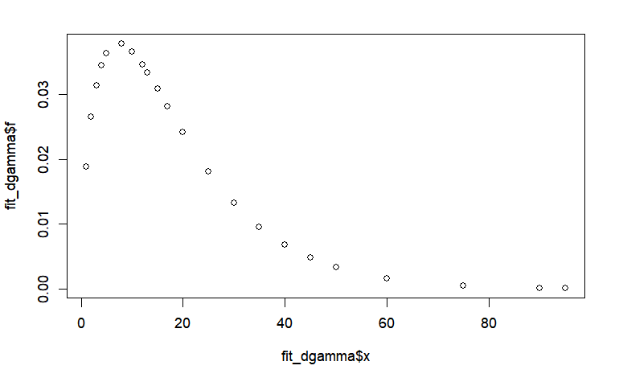

```r
plot(x= fit_dgamma$x, y=fit_dgamma$f)
```

```r
#Calculating exponential distribution
exp_c_2005_ <- fitdistrplus::fitdist(data=cycling_2005$DURATION%>% unlist() %>% as.numeric(), "exp", method="mle", optim.method="Nelder-Mead", weights = round(cycling_2005$WGHT_EPI))
summary(exp_c_2005_)
```

```
Fitting of the distribution ' exp ' by maximum likelihood
Parameters :
```

|  | estimate | Std. Error |
| --- | --- | --- |
| rate | 0.05225869 | 7.148079e-05 |

```
Loglikelihood:  -2110618   AIC:  4221237   BIC:  4221241
```

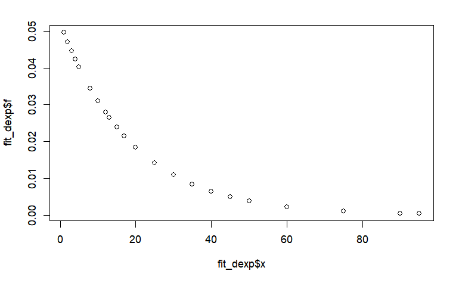

```r
fit_dexp <- data.frame(f = dexp(cycling_2005$DURATION, rate = exp_c_2005_$estimate[1]), x = cycling_2005$DURATION, type = "exp")

plot(x= fit_dexp$x, y=fit_dexp$f)
```

```r
#Calculating weibull distribution
weibull_c_2005_ <- fitdistrplus::fitdist(data=cycling_2005$DURATION%>% unlist() %>% as.numeric(), "weibull", method="mle", optim.method="Nelder-Mead", weights = round(cycling_2005$WGHT_EPI))
summary(weibull_c_2005_)
```

```
Fitting of the distribution ' weibull ' by maximum likelihood
Parameters :
```

|  | estimate | Std. Error |
| --- | --- | --- |
| shape | 1.264939 | 0.00128880 |
| scale | 20.729631 | 0.02375291 |

```
Loglikelihood:  -2087238   AIC:  4174479   BIC:  4174487
Correlation matrix:
          shape     scale
shape 1.0000000 0.3307151
scale 0.3307151 1.0000000
```

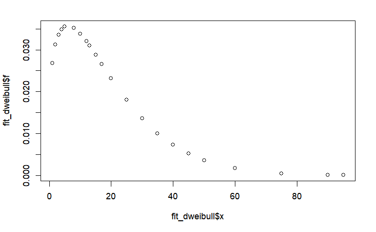

```r
fit_dweibull <- data.frame(f = dweibull(cycling_2005$DURATION, shape = weibull_c_2005_$estimate[1], scale = weibull_c_2005_$estimate[2]), x = cycling_2005$DURATION, type = "weibull")

plot(x= fit_dweibull$x, y=fit_dweibull$f)
```

Now let’s compare these models based on AIC and BIC to see which fits the walk data best:

```r
#comparing these models AIC and BIC to see which fits the walk data best:
broom::glance(MASS::fitdistr(cycling_2005$DURATION%>% unlist() %>% as.numeric(),"gamma"))
```

| logLik | AIC | BIC | nobs |
| --- | --- | --- | --- |
| -1255.696 | 2515.392 | 2522.966 | 326 |

```r
broom::glance(MASS::fitdistr(cycling_2005$DURATION%>% unlist() %>% as.numeric(),"exponential"))
```

| logLik | AIC | BIC | nobs |
| --- | --- | --- | --- |
| -1278.38 | 2558.761 | 2562.547 | 326 |

```r
broom::glance(MASS::fitdistr(cycling_2005$DURATION%>% unlist() %>% as.numeric(),"weibull"))
```

| logLik | AIC | BIC | nobs |
| --- | --- | --- | --- |
| -1261.274 | 2526.548 | 2534.122 | 326 |

So, gamma has largest logLik and the smallest AIC and BIC. we will pick gamma function for cycling trips in 2005!

```r
cycling_2005_gamma <- gamma_c_2005_
cycling_2005 <- cycling_2005 %>%
 mutate(f = dgamma(DURATION, cycling_2005_gamma$estimate[1] , cycling_2005_gamma$estimate[2]))
summary(cycling_2005$f)
```

```
     Min.   1st Qu.    Median      Mean   3rd Qu.      Max.
0.0001106 0.0181189 0.0307792 0.0264687 0.0363136 0.0377005
```

###Destination : Cyling - Home (1), 2005

using a skew vs. kurtois graph to descriptive statistics of data

```
summary statistics
------
min:  1   max:  95
median:  15
mean:  19.6
estimated sd:  16.88146
estimated skewness:  1.73494
estimated kurtosis:  6.283219
```

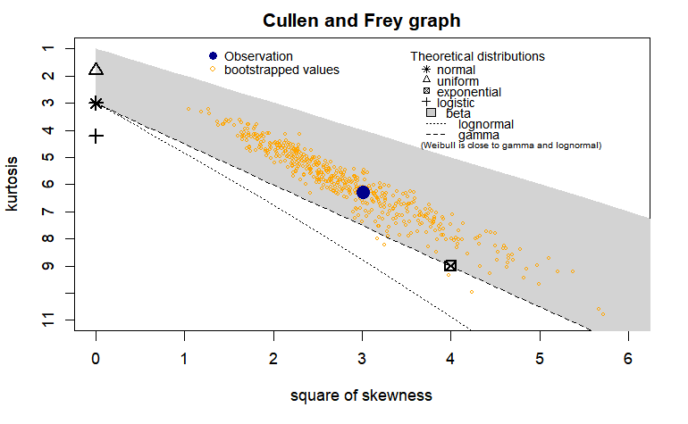

```r
# creating a skew vs. kurtois graph for cycling 2005

# Filter the data based on the "destination" column
 c_1_2005 <- cycling_2005 %>%
  filter(destination == "1")
descdist(c_1_2005$DURATION %>% unlist() %>% as.numeric(), discrete=FALSE, boot=500)
```

As shown in the Cullen and Frey graph, we see that gamma,weibull and exponential will likely be the best fit according to the graph above. Then we compare these models to find the best model.

```r
# Based on the skew vs. kurtois graph the best distribution

#Calculating gamma distribution
gamma_c1_2005_ <- fitdistrplus::fitdist(data=c_1_2005$DURATION%>% unlist() %>% as.numeric(), "gamma", method="mle", optim.method="Nelder-Mead", weights = round(c_1_2005$WGHT_EPI))
fit_dgamma_c105 <- data.frame(f = dgamma(c_1_2005$DURATION, shape = gamma_c1_2005_$estimate[1], rate = gamma_c1_2005_$estimate[2]), x = c_1_2005$DURATION, type = "Gamma")

summary(gamma_c1_2005_)
```

```
Fitting of the distribution ' gamma ' by maximum likelihood
Parameters :
```

|  | estimate | Std. Error |
| --- | --- | --- |
| shape | 1.56768474 | 0.0039779150 |
| rate | 0.07625007 | 0.0002274404 |

```
Loglikelihood:  -1027995   AIC:  2055995   BIC:  2056001
Correlation matrix:
          shape      rate
shape 1.0000000 0.8504423
rate  0.8504423 1.0000000
```

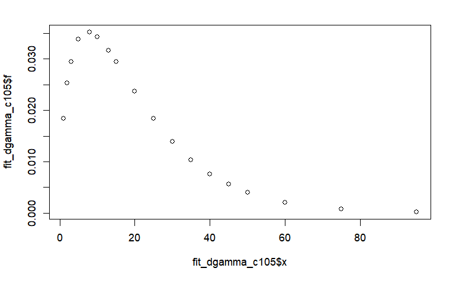

```r
plot(x= fit_dgamma_c105$x, y=fit_dgamma_c105$f)
```

```r
#Calculating weibull distribution
weibull_c1_2005_ <- fitdistrplus::fitdist(data=c_1_2005$DURATION%>% unlist() %>% as.numeric(), "weibull", method="mle", optim.method="Nelder-Mead", weights = round(c_1_2005$WGHT_EPI))
summary(weibull_c1_2005_)
```

```
Fitting of the distribution ' weibull ' by maximum likelihood
Parameters :
```

|  | estimate | Std. Error |
| --- | --- | --- |
| shape | 1.251083 | 0.001850144 |
| scale | 22.201260 | 0.036931476 |

```
Loglikelihood:  -1031690   AIC:  2063384   BIC:  2063390
Correlation matrix:
         shape    scale
shape 1.000000 0.329472
scale 0.329472 1.000000
```

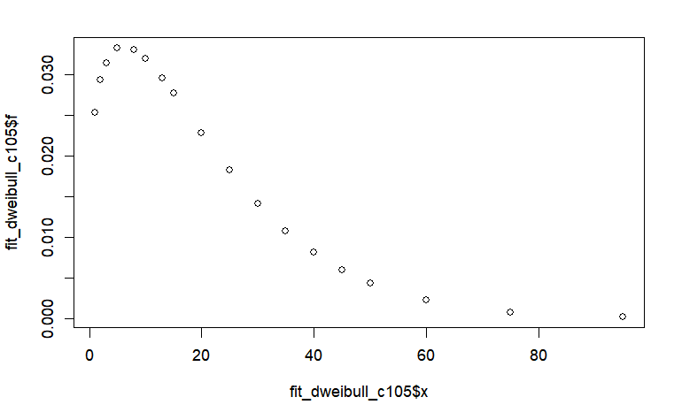

```r
fit_dweibull_c105 <- data.frame(f = dweibull(c_1_2005$DURATION, shape = weibull_c1_2005_$estimate[1], scale = weibull_c1_2005_$estimate[2]), x = c_1_2005$DURATION, type = "weibull")

plot(x= fit_dweibull_c105$x, y=fit_dweibull_c105$f)
```

```r
#Calculating exponential distribution
exp_c1_2005_ <- fitdistrplus::fitdist(data=c_1_2005$DURATION%>% unlist() %>% as.numeric(), "exp", method="mle", optim.method="Nelder-Mead", weights = round(c_1_2005$WGHT_EPI))
summary(exp_c1_2005_)
```

```
Fitting of the distribution ' exp ' by maximum likelihood
Parameters :
```

|  | estimate | Std. Error |
| --- | --- | --- |
| rate | 0.04864876 | 9.555682e-05 |

```
Loglikelihood:  -1041912   AIC:  2083825   BIC:  2083828
```

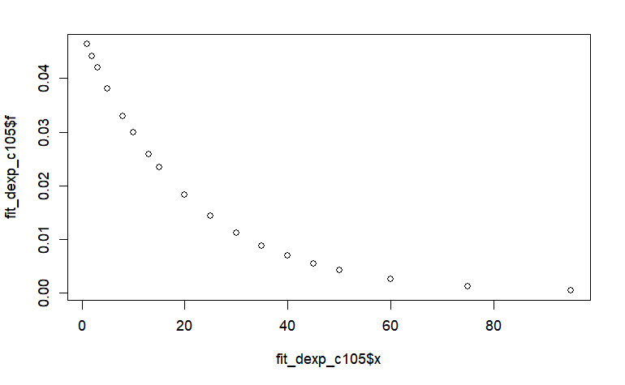

```r
fit_dexp_c105 <- data.frame(f = dexp(c_1_2005$DURATION, rate = exp_c1_2005_$estimate[1]),
                       x = c_1_2005$DURATION, type = "exp")

plot(x = fit_dexp_c105$x, y = fit_dexp_c105$f)
```

Now let’s compare these models AIC and BIC to see which fits the walk data best:

```r
#comparing these models AIC and BIC to see which fits the walk data best:
broom::glance(MASS::fitdistr(c_1_2005$DURATION%>% unlist() %>% as.numeric(),"gamma"))
```

| logLik | AIC | BIC | nobs |
| --- | --- | --- | --- |
| -626.8166 | 1257.633 | 1263.783 | 160 |

```r
broom::glance(MASS::fitdistr(c_1_2005$DURATION%>% unlist() %>% as.numeric(),"weibull"))
```

| logLik | AIC | BIC | nobs |
| --- | --- | --- | --- |
| -629.2528 | 1262.506 | 1268.656 | 160 |

```r
broom::glance(MASS::fitdistr(c_1_2005$DURATION%>% unlist() %>% as.numeric(),"exponential"))
```

| logLik | AIC | BIC | nobs |
| --- | --- | --- | --- |
| -636.0847 | 1274.169 | 1277.245 | 160 |

So, gamma has largest logLik and the smallest AIC and BIC. we will pick gamma function for cycling trips in 2005!

```r
cycling_105_gamma <- gamma_c1_2005_
c_1_2005 <- c_1_2005 %>%
 mutate(f_1 = dgamma(DURATION, cycling_105_gamma$estimate["shape"], cycling_105_gamma$estimate["rate"]))
summary(c_1_2005$f_1)
```

```
     Min.   1st Qu.    Median      Mean   3rd Qu.      Max.
0.0001883 0.0139080 0.0294510 0.0247558 0.0338373 0.0351501
```

###Destination : Cycling - Work or school (2 and 8), 2005

using a skew vs. kurtois graph to descriptive statistics of data

```
summary statistics
------
min:  1   max:  90
median:  15
mean:  21.32877
estimated sd:  18.11925
estimated skewness:  1.563278
estimated kurtosis:  5.300241
```

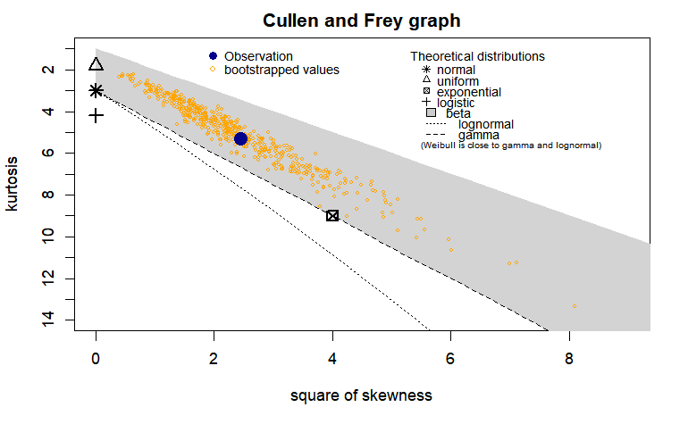

```r
# creating a skew vs. kurtois graph for cycling 2005

# Filter the data based on the "destination" column
 c_2_2005 <- cycling_2005 %>%
  filter(destination %in% c("2", "8"))
descdist(c_2_2005$DURATION %>% unlist() %>% as.numeric(), discrete=FALSE, boot=500)
```

As shown in the Cullen and Frey graph, we see that gamma and exponential will likely be the best fit according to the graph above. Then we compare these models to find the best model.

```r
# Based on the skew vs. kurtois graph the best distribution

#Calculating gamma distribution
gamma_c2_2005_ <- fitdistrplus::fitdist(data=c_2_2005$DURATION%>% unlist() %>% as.numeric(), "gamma", method="mle", optim.method="Nelder-Mead", weights = round(c_2_2005$WGHT_EPI))
fit_dgamma_c205 <- data.frame(f = dgamma(c_2_2005$DURATION, shape = gamma_c2_2005_$estimate[1], rate = gamma_c2_2005_$estimate[2]), x = c_2_2005$DURATION, type = "Gamma")

summary(gamma_c2_2005_)
```

```
Fitting of the distribution ' gamma ' by maximum likelihood
Parameters :
```

|  | estimate | Std. Error |
| --- | --- | --- |
| shape | 1.62801849 | 0.0060345007 |
| rate | 0.07142401 | 0.0003093781 |

```
Loglikelihood:  -495895.3   AIC:  991794.7   BIC:  991799.3
Correlation matrix:
          shape      rate
shape 1.0000000 0.8554503
rate  0.8554503 1.0000000
```

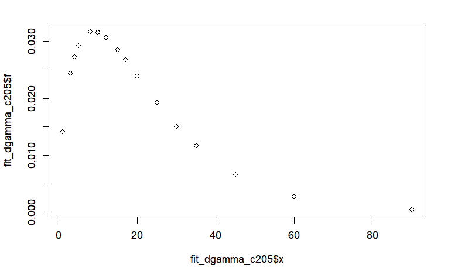

```r
plot(x= fit_dgamma_c205$x, y=fit_dgamma_c205$f)
```

```r
#Calculating exponential distribution
exp_c2_2005_ <- fitdistrplus::fitdist(data=c_2_2005$DURATION%>% unlist() %>% as.numeric(), "exp", method="mle", optim.method="Nelder-Mead", weights = round(c_2_2005$WGHT_EPI))
summary(exp_c2_2005_)
```

```
Fitting of the distribution ' exp ' by maximum likelihood
Parameters :
```

|  | estimate | Std. Error |
| --- | --- | --- |
| rate | 0.04388146 | 0.0001255593 |

```
Loglikelihood:  -503480.8   AIC:  1006964   BIC:  1006966
```

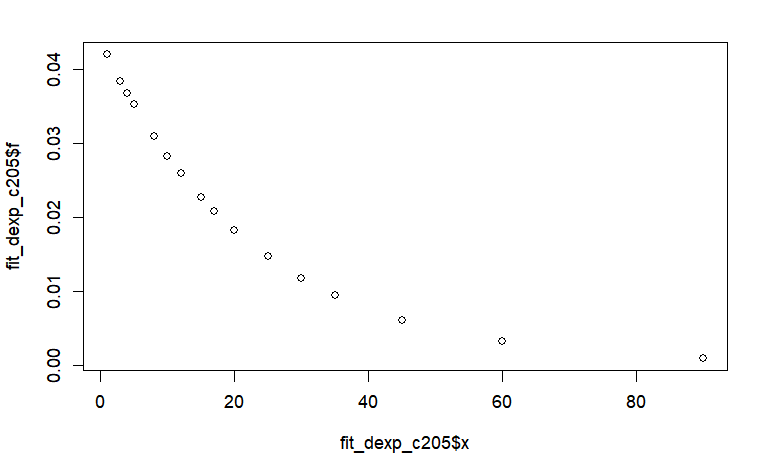

```r
fit_dexp_c205 <- data.frame(f = dexp(c_2_2005$DURATION, rate = exp_c2_2005_$estimate[1]),
                       x = c_2_2005$DURATION, type = "exp")

plot(x = fit_dexp_c205$x, y = fit_dexp_c205$f)
```

Now let’s compare these models AIC and BIC to see which fits the walk data best:

```r
#comparing these models AIC and BIC to see which fits the walk data best:
broom::glance(MASS::fitdistr(c_2_2005$DURATION%>% unlist() %>% as.numeric(),"gamma"))
```

| logLik | AIC | BIC | nobs |
| --- | --- | --- | --- |
| -292.44 | 588.88 | 593.461 | 73 |

```r
broom::glance(MASS::fitdistr(c_2_2005$DURATION%>% unlist() %>% as.numeric(),"exponential"))
```

| logLik | AIC | BIC | nobs |
| --- | --- | --- | --- |
| -296.3841 | 594.7683 | 597.0587 | 73 |

So, gamma has largest logLik and the smallest AIC and BIC. we will pick gamma function for cycling trips in 2005!

```r
cycling_205_gamma <- gamma_c2_2005_
c_2_2005 <- c_2_2005 %>%
 mutate(f_2 = dgamma(DURATION, cycling_205_gamma$estimate["shape"], cycling_205_gamma$estimate["rate"]))
summary(c_2_2005$f_2)
```

```
     Min.   1st Qu.    Median      Mean   3rd Qu.      Max.
0.0004139 0.0150780 0.0284825 0.0224608 0.0291828 0.0316418
```

###Destination : cycling - other’s home (3), 2005

using a skew vs. kurtois graph to descriptive statistics of data

```
summary statistics
------
min:  1   max:  35
median:  15
mean:  14.1
estimated sd:  9.632381
estimated skewness:  0.5620407
estimated kurtosis:  2.269728
```

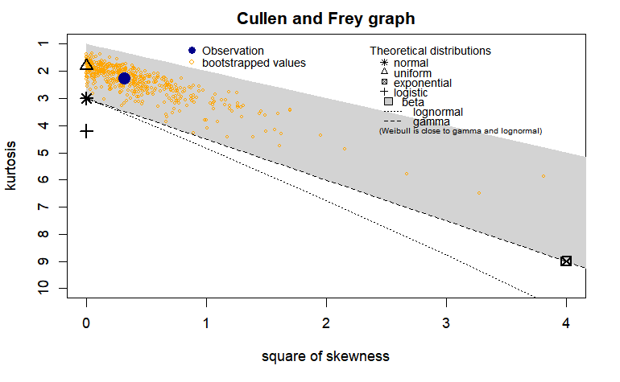

```r
# creating a skew vs. kurtois graph for cycling 2005

# Filter the data based on the "destination" column
 c_3_2005 <- cycling_2005 %>%
  filter(destination == "3")
descdist(c_3_2005$DURATION %>% unlist() %>% as.numeric(), discrete=FALSE, boot=500)
```

As shown in the Cullen and Frey graph, we see that poisson, gamma and normal will likely be the best fit according to the graph above. Then we compare these models to find the best model.

```r
# Based on the skew vs. kurtois graph the best distribution

#Calculating normal distribution
norm_c3_2005_ <- fitdistrplus::fitdist(data=c_3_2005$DURATION%>% unlist() %>% as.numeric(), "norm", method="mle", optim.method="Nelder-Mead", weights = round(c_3_2005$WGHT_EPI))
fit_dnorm_c305 <- data.frame(f = dnorm(c_3_2005$DURATION, mean = norm_c3_2005_$estimate[1], sd = norm_c3_2005_$estimate[2]), x = c_3_2005$DURATION, type = "norm")

summary(norm_c3_2005_)
```

```
Fitting of the distribution ' norm ' by maximum likelihood
Parameters :
```

|  | estimate | Std. Error |
| --- | --- | --- |
| mean | 12.124907 | 0.03795962 |
| sd | 8.550188 | 0.02684018 |

```
Loglikelihood:  -180866.5   AIC:  361736.9   BIC:  361739.7
Correlation matrix:
             mean           sd
mean 1.0000000000 0.0002155865
sd   0.0002155865 1.0000000000
```

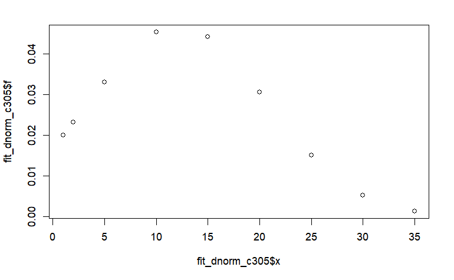

```r
plot(x= fit_dnorm_c305$x, y=fit_dnorm_c305$f)
```

```r
#Calculating gamma distribution
gamma_c3_2005_ <- fitdistrplus::fitdist(data=c_3_2005$DURATION%>% unlist() %>% as.numeric(), "gamma", method="mle", optim.method="Nelder-Mead", weights = round(c_3_2005$WGHT_EPI))
fit_dgamma_c305 <- data.frame(f = dgamma(c_3_2005$DURATION, shape = gamma_c3_2005_$estimate[1], rate = gamma_c3_2005_$estimate[2]), x = c_3_2005$DURATION, type = "gamma")

summary(gamma_c3_2005_)
```

```
Fitting of the distribution ' gamma ' by maximum likelihood
Parameters :
```

|  | estimate | Std. Error |
| --- | --- | --- |
| shape | 1.8471891 | 0.010714192 |
| rate | 0.1523545 | 0.001014133 |

```
Loglikelihood:  -172574.4   AIC:  345152.8   BIC:  345155.6
Correlation matrix:
          shape      rate
shape 1.0000000 0.8713185
rate  0.8713185 1.0000000
```

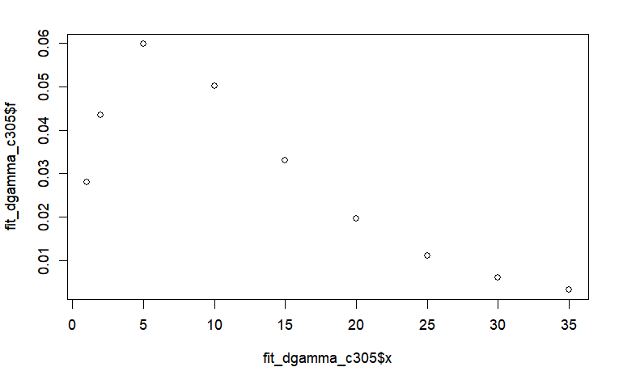

```r
plot(x= fit_dgamma_c305$x, y=fit_dgamma_c305$f)
```

```r
#Calculating poisson distribution
pois_c3_2005_ <- fitdistrplus::fitdist(data=c_3_2005$DURATION%>% unlist() %>% as.numeric(), "pois", method="mle", optim.method="Nelder-Mead", weights = round(c_3_2005$WGHT_EPI))
summary(pois_c3_2005_)
```

```
Fitting of the distribution ' pois ' by maximum likelihood
Parameters :
```

|  | estimate | Std. Error |
| --- | --- | --- |
| lambda | 12.12407 | 0.01545891 |

```
Loglikelihood:  -254200.4   AIC:  508402.8   BIC:  508404.2
```

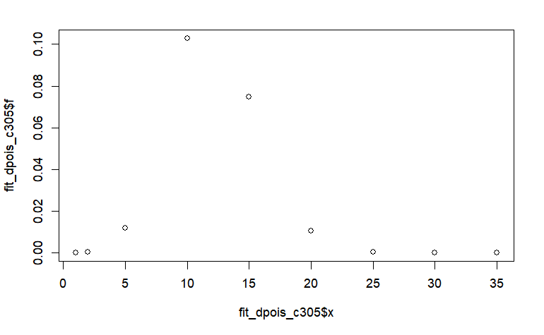

```r
fit_dpois_c305 <- data.frame(f = dpois(c_3_2005$DURATION, lambda = pois_c3_2005_$estimate[1]),
                       x = c_3_2005$DURATION, type = "pois")

plot(x = fit_dpois_c305$x, y = fit_dpois_c305$f)
```

Now let’s compare these models AIC and BIC to see which fits the walk data best:

```r
#comparing these models AIC and BIC to see which fits the walk data best:
broom::glance(MASS::fitdistr(c_3_2005$DURATION%>% unlist() %>% as.numeric(),"poisson"))
```

| logLik | AIC | BIC | nobs |
| --- | --- | --- | --- |
| -161.6181 | 325.2361 | 326.6373 | 30 |

```r
broom::glance(MASS::fitdistr(c_3_2005$DURATION%>% unlist() %>% as.numeric(),"gamma"))
```

| logLik | AIC | BIC | nobs |
| --- | --- | --- | --- |
| -106.6052 | 217.2104 | 220.0128 | 30 |

```r
broom::glance(MASS::fitdistr(c_3_2005$DURATION%>% unlist() %>% as.numeric(),"normal"))
```

| logLik | AIC | BIC | nobs |
| --- | --- | --- | --- |
| -110.0135 | 224.0271 | 226.8295 | 30 |

```r
cycling_305_gamma <- gamma_c3_2005_
c_3_2005 <- c_3_2005 %>%
 mutate(f_3 = dgamma(DURATION, cycling_305_gamma$estimate["shape"], cycling_305_gamma$estimate["rate"]))
summary(c_3_2005$f_3)
```

```
    Min.  1st Qu.   Median     Mean  3rd Qu.     Max.
0.003218 0.019685 0.033047 0.036028 0.059784 0.059784
```

###Destination : cycling - Restaurant/bar (4), 2005

using a skew vs. kurtois graph to descriptive statistics of data

```
summary statistics
------
min:  5   max:  35
median:  20
mean:  20.5
estimated sd:  10.39498
estimated skewness:  -0.07233571
estimated kurtosis:  1.494232
```

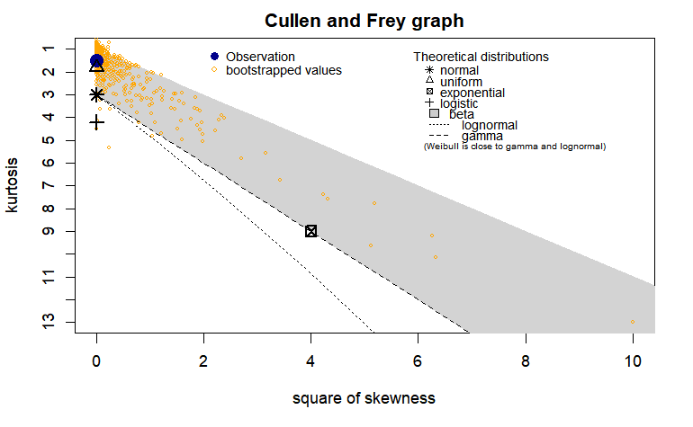

```r
# creating a skew vs. kurtois graph for cycling 2005

# Filter the data based on the "destination" column
 c_4_2005 <- cycling_2005 %>%
  filter(destination == "4")
descdist(c_4_2005$DURATION %>% unlist() %>% as.numeric(), discrete=FALSE, boot=500)
```

As shown in the Cullen and Frey graph, we see that normal, poisson, gamma and exponential will likely be the best fit according to the graph above. Then we compare these models to find the best model.

```r
# Based on the skew vs. kurtois graph the best distribution

#Calculating normal distribution
norm_c4_2005_ <- fitdistrplus::fitdist(data=c_4_2005$DURATION%>% unlist() %>% as.numeric(), "norm", method="mle", optim.method="Nelder-Mead", weights = round(c_4_2005$WGHT_EPI))
fit_dnorm_c405 <- data.frame(f = dnorm(c_4_2005$DURATION, mean = norm_c4_2005_$estimate[1], sd = norm_c4_2005_$estimate[2]), x = c_4_2005$DURATION, type = "norm")

summary(norm_c4_2005_)
```

```
Fitting of the distribution ' norm ' by maximum likelihood
Parameters :
```

|  | estimate | Std. Error |
| --- | --- | --- |
| mean | 16.344107 | 0.07178629 |
| sd | 8.898894 | 0.05075411 |

```
Loglikelihood:  -55397.27   AIC:  110798.5   BIC:  110799.1
Correlation matrix:
              mean            sd
mean  1.000000e+00 -5.288993e-05
sd   -5.288993e-05  1.000000e+00
```

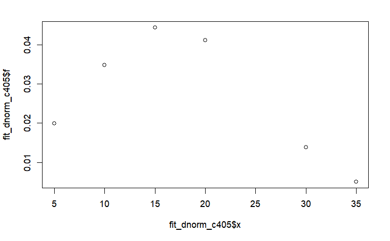

```r
plot(x= fit_dnorm_c405$x, y=fit_dnorm_c405$f)
```

```r
#Calculating poisson distribution
pois_c4_2005_ <- fitdistrplus::fitdist(data=c_4_2005$DURATION%>% unlist() %>% as.numeric(), "pois", method="mle", optim.method="Nelder-Mead", weights = round(c_4_2005$WGHT_EPI))
summary(pois_c4_2005_)
```

```
Fitting of the distribution ' pois ' by maximum likelihood
Parameters :
```

|  | estimate | Std. Error |
| --- | --- | --- |
| lambda | 16.34395 | 0.03261199 |

```
Loglikelihood:  -72630.61   AIC:  145263.2   BIC:  145263.5
```

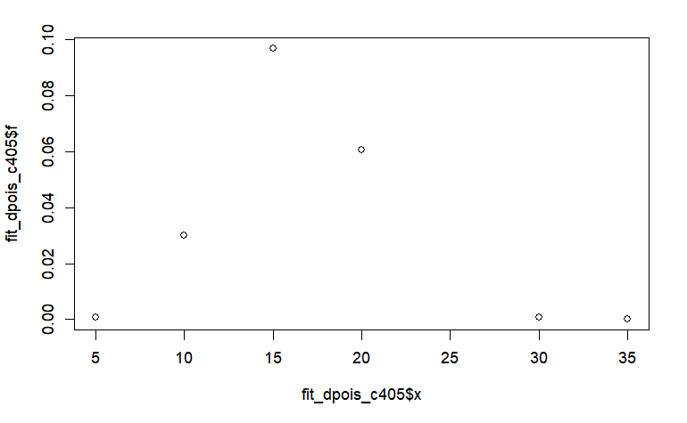

```r
fit_dpois_c405 <- data.frame(f = dpois(c_4_2005$DURATION, lambda = pois_c4_2005_$estimate[1]), x = c_4_2005$DURATION, type = "pois")

plot(x= fit_dpois_c405$x, y=fit_dpois_c405$f)
```

```r
#Calculating gamma distribution
gamma_c4_2005_ <- fitdistrplus::fitdist(data=c_4_2005$DURATION%>% unlist() %>% as.numeric(), "gamma", method="mle", optim.method="Nelder-Mead", weights = round(c_4_2005$WGHT_EPI))
summary(gamma_c4_2005_)
```

```
Fitting of the distribution ' gamma ' by maximum likelihood
Parameters :
```

|  | estimate | Std. Error |
| --- | --- | --- |
| shape | 2.9869320 | 0.032350445 |
| rate | 0.1827472 | 0.002155151 |

```
Loglikelihood:  -54468.59   AIC:  108941.2   BIC:  108941.8
Correlation matrix:
          shape      rate
shape 1.0000000 0.9183458
rate  0.9183458 1.0000000
```

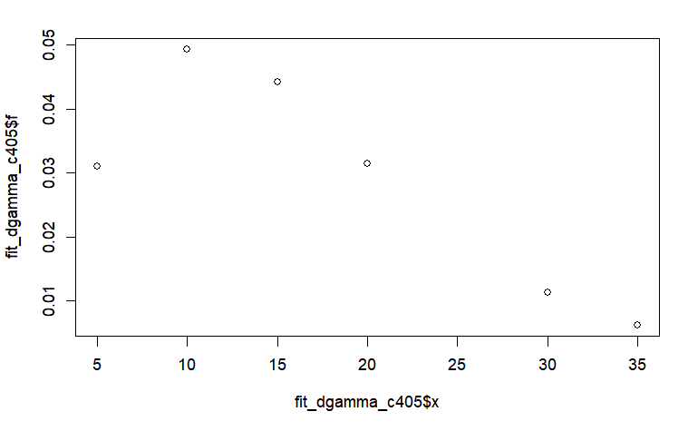

```r
fit_dgamma_c405 <- data.frame(f = dgamma(c_4_2005$DURATION, shape = gamma_c4_2005_$estimate[1], rate = gamma_c4_2005_$estimate[2]), x = c_4_2005$DURATION, type = "gamma")

plot(x= fit_dgamma_c405$x, y=fit_dgamma_c405$f)
```

```r
#Calculating exponential distribution
exp_c4_2005_ <- fitdistrplus::fitdist(data=c_4_2005$DURATION%>% unlist() %>% as.numeric(), "exp", method="mle", optim.method="Nelder-Mead", weights = round(c_4_2005$WGHT_EPI))
summary(exp_c4_2005_)
```

```
Fitting of the distribution ' exp ' by maximum likelihood
Parameters :
```

|  | estimate | Std. Error |
| --- | --- | --- |
| rate | 0.06116616 | 0.000493288 |

```
Loglikelihood:  -58300.67   AIC:  116603.3   BIC:  116603.6
```

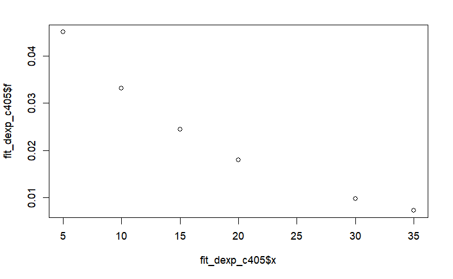

```r
fit_dexp_c405 <- data.frame(f = dexp(c_4_2005$DURATION, rate = exp_c4_2005_$estimate[1]),
                       x = c_4_2005$DURATION, type = "exp")

plot(x = fit_dexp_c405$x, y = fit_dexp_c405$f)
```

Now let’s compare these models AIC and BIC to see which fits the walk data best:

```r
#comparing these models AIC and BIC to see which fits the walk data best:
broom::glance(MASS::fitdistr(c_4_2005$DURATION%>% unlist() %>% as.numeric(),"normal"))
```

| logLik | AIC | BIC | nobs |
| --- | --- | --- | --- |
| -37.07581 | 78.15162 | 78.75679 | 10 |

```r
broom::glance(MASS::fitdistr(c_4_2005$DURATION%>% unlist() %>% as.numeric(),"poisson"))
```

| logLik | AIC | BIC | nobs |
| --- | --- | --- | --- |
| -49.4906 | 100.9812 | 101.2838 | 10 |

```r
broom::glance(MASS::fitdistr(c_4_2005$DURATION%>% unlist() %>% as.numeric(),"gamma"))
```

| logLik | AIC | BIC | nobs |
| --- | --- | --- | --- |
| -37.19389 | 78.38777 | 78.99294 | 10 |

```r
broom::glance(MASS::fitdistr(c_4_2005$DURATION%>% unlist() %>% as.numeric(),"exponential"))
```

| logLik | AIC | BIC | nobs |
| --- | --- | --- | --- |
| -40.20425 | 82.4085 | 82.71108 | 10 |

So, normal has largest logLik and the smallest AIC and BIC. we will pick normal function for cycling trips in 2005!

```r
cycling_405_norm <- norm_c4_2005_
c_4_2005 <- c_4_2005 %>%
 mutate(f_4 = dnorm(DURATION, cycling_405_norm$estimate["mean"], cycling_405_norm$estimate["sd"]))
summary(c_4_2005$f_4)
```

```
   Min. 1st Qu.  Median    Mean 3rd Qu.    Max.
0.00498 0.01381 0.02733 0.02626 0.03959 0.04432
```

###Destination : Cycling - Place of worship (5), 2005

using a skew vs. kurtois graph to descriptive statistics of data

```r
# creating a skew vs. kurtois graph for cycling 2005

# Filter the data based on the "destination" column
 c_5_2005 <- cycling_2005 %>%
  filter(destination == "5")
count <- sum(cycling_2005$destination == "5")
print(count)
```

```
[1] 0
```

```r
#descdist(c_5_2005$DURATION %>% unlist() %>% as.numeric(), discrete=FALSE, boot=500)
```

###Destination :Grocery store, other stores or mall (6 and 7)

```r
# creating a skew vs. kurtois graph for cycling 2005

# Filter the data based on the "destination" column
 c_6_2005 <- cycling_2005 %>%
  filter(destination %in% c("6", "7"))
descdist(c_6_2005$DURATION %>% unlist() %>% as.numeric(), discrete=FALSE, boot=500)
```

[output not shown]

```r
# Based on the skew vs. kurtois graph the best distribution

#Calculating gamma distribution
gamma_c6_2005_ <- fitdistrplus::fitdist(data=c_6_2005$DURATION%>% unlist() %>% as.numeric(), "gamma", method="mle", optim.method="Nelder-Mead", weights = round(c_6_2005$WGHT_EPI))
fit_dgamma_c605 <- data.frame(f = dgamma(c_6_2005$DURATION, shape = gamma_c6_2005_$estimate[1], rate = gamma_c6_2005_$estimate[2]), x = c_6_2005$DURATION, type = "Gamma")

summary(gamma_c6_2005_)
```

```
Fitting of the distribution ' gamma ' by maximum likelihood
Parameters :
```

|  | estimate | Std. Error |
| --- | --- | --- |
| shape | 2.0917787 | 0.011761279 |
| rate | 0.1666651 | 0.001058341 |

```
Loglikelihood:  -186558.6   AIC:  373121.2   BIC:  373124.2
Correlation matrix:
          shape      rate
shape 1.0000000 0.8853845
rate  0.8853845 1.0000000
```

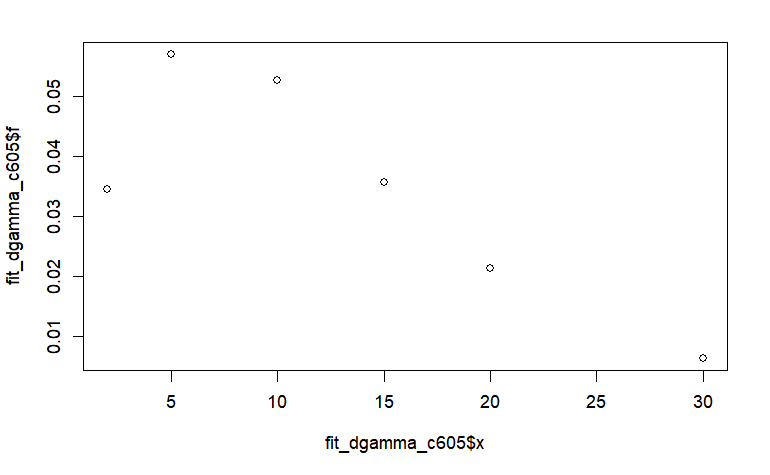

```r
plot(x= fit_dgamma_c605$x, y=fit_dgamma_c605$f)
```

```r
#Calculating poisson distribution
pois_c6_2005_ <- fitdistrplus::fitdist(data=c_6_2005$DURATION%>% unlist() %>% as.numeric(), "pois", method="mle", optim.method="Nelder-Mead", weights = round(c_6_2005$WGHT_EPI))
summary(pois_c6_2005_)
```

```
Fitting of the distribution ' pois ' by maximum likelihood
Parameters :
```

|  | estimate | Std. Error |
| --- | --- | --- |
| lambda | 12.55254 | 0.01512692 |

```
Loglikelihood:  -277183.6   AIC:  554369.1   BIC:  554370.6
```

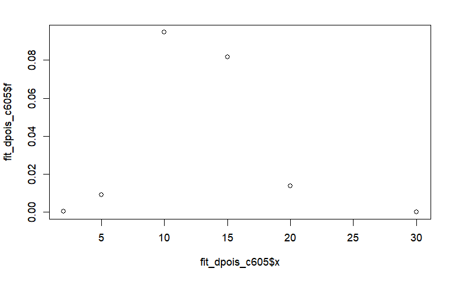

```r
fit_dpois_c605 <- data.frame(f = dpois(c_6_2005$DURATION, lambda = pois_c6_2005_$estimate[1]), x = c_6_2005$DURATION, type = "pois")

plot(x= fit_dpois_c605$x, y=fit_dpois_c605$f)
```

```r
#Calculating exponential distribution
exp_c6_2005_ <- fitdistrplus::fitdist(data=c_6_2005$DURATION%>% unlist() %>% as.numeric(), "exp", method="mle", optim.method="Nelder-Mead", weights = round(c_6_2005$WGHT_EPI))
summary(exp_c6_2005_)
```

```
Fitting of the distribution ' exp ' by maximum likelihood
Parameters :
```

|  | estimate | Std. Error |
| --- | --- | --- |
| rate | 0.07965583 | 0.0003400362 |

```
Loglikelihood:  -193645.8   AIC:  387293.7   BIC:  387295.2
```

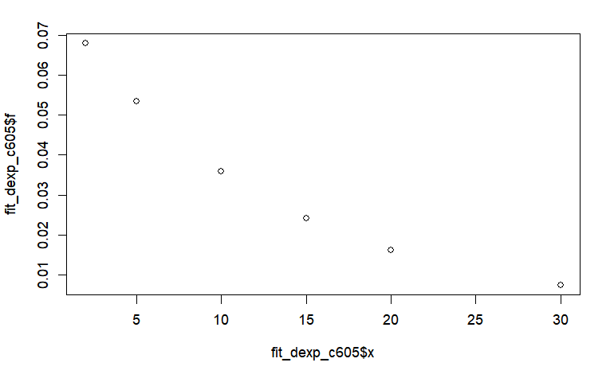

```r
fit_dexp_c605 <- data.frame(f = dexp(c_6_2005$DURATION, rate = exp_c6_2005_$estimate[1]),
                       x = c_6_2005$DURATION, type = "exp")

plot(x = fit_dexp_c605$x, y = fit_dexp_c605$f)
```

Now let’s compare these models AIC and BIC to see which fits the walk data best:

```r
#comparing these models AIC and BIC to see which fits the walk data best:
broom::glance(MASS::fitdistr(c_6_2005$DURATION%>% unlist() %>% as.numeric(),"gamma"))
```

| logLik | AIC | BIC | nobs |
| --- | --- | --- | --- |
| -110.0713 | 224.1426 | 227.1356 | 33 |

```r
broom::glance(MASS::fitdistr(c_6_2005$DURATION%>% unlist() %>% as.numeric(),"poisson"))
```

| logLik | AIC | BIC | nobs |
| --- | --- | --- | --- |
| -154.3314 | 310.6627 | 312.1592 | 33 |

```r
broom::glance(MASS::fitdistr(c_6_2005$DURATION%>% unlist() %>% as.numeric(),"exponential"))
```

| logLik | AIC | BIC | nobs |
| --- | --- | --- | --- |
| -115.9061 | 233.8122 | 235.3087 | 33 |

So, gamma has largest logLik and the smallest AIC and BIC. we will pick gamma function for cycling trips in 2005!

```r
cycling_605_gamma <- gamma_c6_2005_
c_6_2005 <- c_6_2005 %>%
 mutate(f_6 = dgamma(DURATION, cycling_605_gamma$estimate["shape"], cycling_605_gamma$estimate["rate"]))
summary(c_6_2005$f_6)
```

```
    Min.  1st Qu.   Median     Mean  3rd Qu.     Max.
0.006245 0.035692 0.052750 0.042884 0.056947 0.056947
```

###Destination : Cycling - Outdoors (9), 2005

using a skew vs. kurtois graph to descriptive statistics of data

```
summary statistics
------
min:  5   max:  45
median:  15
mean:  16.25
estimated sd:  9.441649
estimated skewness:  1.423256
estimated kurtosis:  6.61743
```

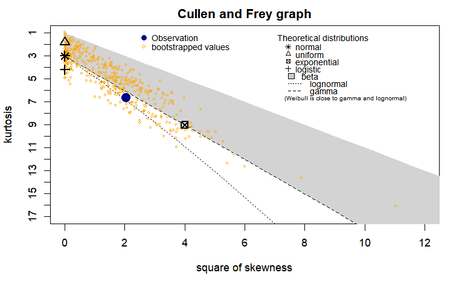

```r
# creating a skew vs. kurtois graph for cycling 2005

# Filter the data based on the "destination" column
 c_9_2005 <- cycling_2005 %>%
  filter(destination == "9")
descdist(c_9_2005$DURATION %>% unlist() %>% as.numeric(), discrete=FALSE, boot=500)
```

As shown in the Cullen and Frey graph, we see that gamma,normal, weibull, lognormal and exponential will likely be the best fit according to the graph above. Then we compare these models to find the best model.

```r
# Based on the skew vs. kurtois graph the best distribution

#Calculating gamma distribution
gamma_c9_2005_ <- fitdistrplus::fitdist(data=c_9_2005$DURATION%>% unlist() %>% as.numeric(), "gamma", method="mle", optim.method="Nelder-Mead", weights = round(c_9_2005$WGHT_EPI))
fit_dgamma_c905 <- data.frame(f = dgamma(c_9_2005$DURATION, shape = gamma_c9_2005_$estimate[1], rate = gamma_c9_2005_$estimate[2]), x = c_9_2005$DURATION, type = "Gamma")

summary(gamma_c9_2005_)
```

```
Fitting of the distribution ' gamma ' by maximum likelihood
Parameters :
```

|  | estimate | Std. Error |
| --- | --- | --- |
| shape | 3.1227360 | 0.02343115 |
| rate | 0.1784454 | 0.00145250 |

```
Loglikelihood:  -115613.3   AIC:  231230.5   BIC:  231232.5
Correlation matrix:
          shape      rate
shape 1.0000000 0.9217749
rate  0.9217749 1.0000000
```

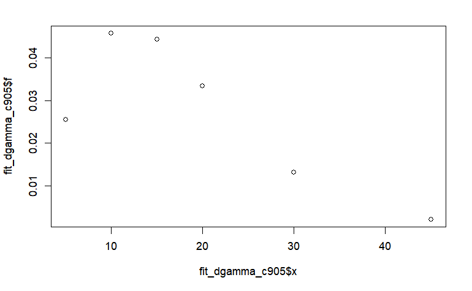

```r
plot(x= fit_dgamma_c905$x, y=fit_dgamma_c905$f)
```

```r
#Calculating exponential distribution
exp_c9_2005_ <- fitdistrplus::fitdist(data=c_9_2005$DURATION%>% unlist() %>% as.numeric(), "exp", method="mle", optim.method="Nelder-Mead", weights = round(c_9_2005$WGHT_EPI))
summary(exp_c9_2005_)
```

```
Fitting of the distribution ' exp ' by maximum likelihood
Parameters :
```

|  | estimate | Std. Error |
| --- | --- | --- |
| rate | 0.05713942 | 0.0003185804 |

```
Loglikelihood:  -124163.5   AIC:  248328.9   BIC:  248329.9
```

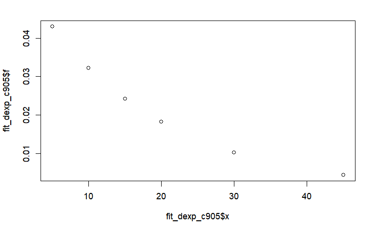

```r
fit_dexp_c905 <- data.frame(f = dexp(c_9_2005$DURATION, rate = exp_c9_2005_$estimate[1]),
                       x = c_9_2005$DURATION, type = "exp")

plot(x = fit_dexp_c905$x, y = fit_dexp_c905$f)
```

```r
#Calculating normal distribution
norm_c9_2005_ <- fitdistrplus::fitdist(data=c_9_2005$DURATION%>% unlist() %>% as.numeric(), "norm", method="mle", optim.method="Nelder-Mead", weights = round(c_9_2005$WGHT_EPI))
summary(norm_c9_2005_)
```

```
Fitting of the distribution ' norm ' by maximum likelihood
Parameters :
```

|  | estimate | Std. Error |
| --- | --- | --- |
| mean | 17.49557 | 0.05721813 |
| sd | 10.25929 | 0.04046739 |

```
Loglikelihood:  -120462   AIC:  240927.9   BIC:  240929.9
Correlation matrix:
              mean            sd
mean  1.0000000000 -0.0004279326
sd   -0.0004279326  1.0000000000
```

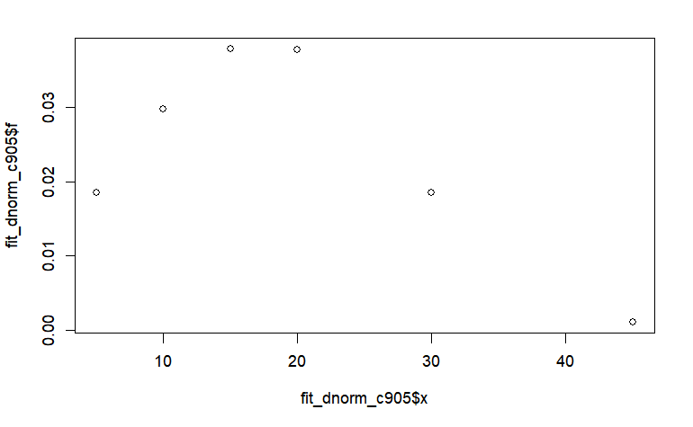

```r
fit_dnorm_c905 <- data.frame(f = dnorm(c_9_2005$DURATION, mean = norm_c9_2005_$estimate[1], sd = norm_c9_2005_$estimate[2]),  x = c_9_2005$DURATION, type = "norm")

plot(x = fit_dnorm_c905$x, y = fit_dnorm_c905$f)
```

```r
#Calculating weibull distribution
weibull_c9_2005_ <- fitdistrplus::fitdist(data=c_9_2005$DURATION%>% unlist() %>% as.numeric(), "weibull", method="mle", optim.method="Nelder-Mead", weights = round(c_9_2005$WGHT_EPI))
summary(weibull_c9_2005_)
```

```
Fitting of the distribution ' weibull ' by maximum likelihood
Parameters :
```

|  | estimate | Std. Error |
| --- | --- | --- |
| shape | 1.819516 | 0.007484241 |
| scale | 19.773535 | 0.064150643 |

```
Loglikelihood:  -116517.2   AIC:  233038.3   BIC:  233040.3
Correlation matrix:
          shape     scale
shape 1.0000000 0.3280302
scale 0.3280302 1.0000000
```

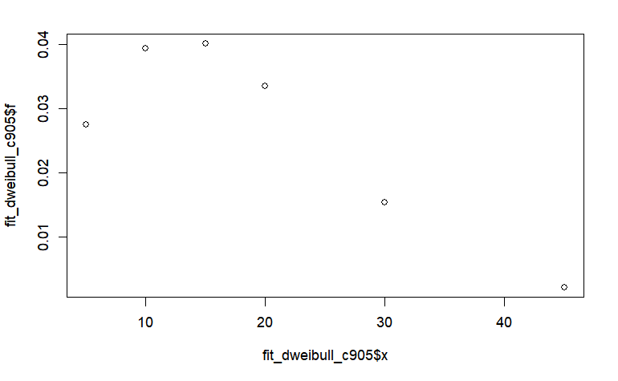

```r
fit_dweibull_c905 <- data.frame(f = dweibull(c_9_2005$DURATION, shape = weibull_c9_2005_$estimate[1], scale = weibull_c9_2005_$estimate[2]),  x = c_9_2005$DURATION, type = "weibull")

plot(x = fit_dweibull_c905$x, y = fit_dweibull_c905$f)
```

```r
#Calculating lognormal distribution
lnorm_c9_2005_ <- fitdistrplus::fitdist(data=c_9_2005$DURATION%>% unlist() %>% as.numeric(), "lnorm", method="mle", optim.method="Nelder-Mead", weights = round(c_9_2005$WGHT_EPI))
summary(lnorm_c9_2005_)
```

```
Fitting of the distribution ' lnorm ' by maximum likelihood
Parameters :
```

|  | estimate | Std. Error |
| --- | --- | --- |
| meanlog | 2.693438 | 0.003358401 |
| sdlog | 0.602166 | 0.002374368 |

```
Loglikelihood:  -115908.5   AIC:  231821.1   BIC:  231823.1
Correlation matrix:
              meanlog         sdlog
meanlog  1.0000000000 -0.0002375061
sdlog   -0.0002375061  1.0000000000
```

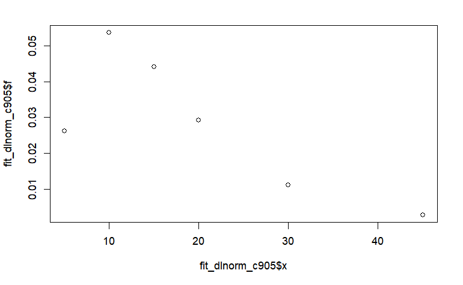

```r
fit_dlnorm_c905 <- data.frame(f = dlnorm(c_9_2005$DURATION, meanlog = lnorm_c9_2005_$estimate[1], sdlog = lnorm_c9_2005_$estimate[2]),  x = c_9_2005$DURATION, type = "lnorm")

plot(x = fit_dlnorm_c905$x, y = fit_dlnorm_c905$f)
```

Now let’s compare these models AIC and BIC to see which fits the walk data best:

```r
#comparing these models AIC and BIC to see which fits the walk data best:
broom::glance(MASS::fitdistr(c_9_2005$DURATION%>% unlist() %>% as.numeric(),"gamma"))
```

| logLik | AIC | BIC | nobs |
| --- | --- | --- | --- |
| -70.26274 | 144.5255 | 146.5169 | 20 |

```r
broom::glance(MASS::fitdistr(c_9_2005$DURATION%>% unlist() %>% as.numeric(),"weibull"))
```

| logLik | AIC | BIC | nobs |
| --- | --- | --- | --- |
| -70.66698 | 145.334 | 147.3254 | 20 |

```r
broom::glance(MASS::fitdistr(c_9_2005$DURATION%>% unlist() %>% as.numeric(),"lognormal"))
```

| logLik | AIC | BIC | nobs |
| --- | --- | --- | --- |
| -70.63321 | 145.2664 | 147.2579 | 20 |

```r
broom::glance(MASS::fitdistr(c_9_2005$DURATION%>% unlist() %>% as.numeric(),"exponential"))
```

| logLik | AIC | BIC | nobs |
| --- | --- | --- | --- |
| -75.76186 | 153.5237 | 154.5194 | 20 |

```r
broom::glance(MASS::fitdistr(c_9_2005$DURATION%>% unlist() %>% as.numeric(),"normal"))
```

| logLik | AIC | BIC | nobs |
| --- | --- | --- | --- |
| -72.76845 | 149.5369 | 151.5284 | 20 |

So, gamma has largest logLik and the smallest AIC and BIC. we will pick gamma function for cycling trips in 2005!

```r
cycling_905_gamma <- gamma_c9_2005_
c_9_2005 <- c_9_2005 %>%
 mutate(f_9 = dgamma(DURATION, cycling_905_gamma$estimate["shape"], cycling_905_gamma$estimate["rate"]))
summary(c_9_2005$f_9)
```

```
    Min.  1st Qu.   Median     Mean  3rd Qu.     Max.
0.002153 0.025550 0.033338 0.033695 0.044180 0.045595
```

###Destination : Cycling -Outdoors (10), 2005

using a skew vs. kurtois graph to descriptive statistics of data

```r
# creating a skew vs. kurtois graph for cycling 2005

# Filter the data based on the "destination" column
c_10_2005 <- cycling_2005 %>%
  filter(destination == "10")
count <- sum (cycling_2005$destination == "10")
print (count)
```

```
[1] 0
```

```r
#descdist(c_10_2005$DURATION %>% unlist() %>% as.numeric(), discrete=FALSE, boot=500)
```

```r
walking_2005_f <- bind_rows(w_1_2005, w_2_2005, w_3_2005, w_4_2005, w_5_2005, w_6_2005, w_9_2005, w_10_2005)
```

```r
cycling_2005_f <- bind_rows(c_1_2005, c_2_2005, c_3_2005,c_4_2005, c_6_2005, c_9_2005)
```